# 假設檢定：從研究問題到統計決策

Week 07 Part 2｜模型、證據與錯誤風險

HT3001B 生物統計學與 R

2026-10-22

## 66 人中，有 20 人剛好得到 80 分

一場選擇題考試，66 位考生中，20 位的成績都是 80 分。

$$\widehat{\pi}=\frac{20}{66}\approx 30.3\%$$

- 這個比例看起來很高，但「很高」要和什麼比較？
- 若過去同類考試約有 15% 的人剛好得到 80 分，這次是否特別？

**先建立比較基準，才能談罕見程度。**

IMS 2e §16.1

## 「偏離基準」與「知道原因」是兩件事

先把 15% 當成這個教學案例的假設基準。

| 問題 | 目前資料能做什麼？ |
| --- | --- |
| 20 人同分，與基準模型是否相容？ | 在模型下計算罕見程度 |
| 為什麼會有這麼多人同分？ | 還需要題目、評分與作答過程的證據 |

**即使與基準不相容，也不能單憑這個結果判定作弊。**

IMS 2e §16.1.1

## 假設談母體；樣本提供證據

母體參數（population parameter）是想了解的對象。

| 對象 | 母體參數 | 樣本統計量（sample statistic） |
| --- | --- | --- |
| 剛好 80 分的比例 | $\pi$ | $\widehat{\pi}=20/66$ |
| 量表分數的平均 | $\mu$ | $\bar x$ |

樣本比例已經知道；真正要問的是，它對母體比例提供什麼證據。

**寫假設時用 $\pi$ 或 $\mu$，不要把已觀察到的樣本值當成待檢定參數。**

IMS 2e §2.1.2

## 把兩個競爭主張寫完整

虛無假設（null hypothesis）記為 $H_0$；對立假設（alternative hypothesis）記為 $H_1$。

| 問題 | $H_0$ | $H_1$ |
| --- | --- | --- |
| 同分比例是否不同於 15%？ | $\pi=0.15$ | $\pi\ne0.15$ |
| 平均年齡是否高於 39 歲？ | $\mu\le39$ | $\mu>39$ |
| 平均分數是否低於 96 分？ | $\mu\ge96$ | $\mu<96$ |

**兩個假設互補；不能漏掉等號，也不能把方向寫成重疊的範圍。**

IMS 2e §11.3、§14.2

## 為什麼先從 $H_0$ 出發？

假設檢定（hypothesis testing）先問：

如果 $H_0$ 與模型條件成立，像這樣的資料會多常出現？

- $H_0$ 與其他模型條件一起提供可比較的參考分布。
- $H_1$ 可能包含許多不同的效果大小；拒絕 $H_0$ 不等於證明某個特定原因。

**先算「假如模型成立」的結果，再回頭評估觀察資料。**

IMS 2e §11.3、§16.1.2

## 一個觀察值，要放回一整個參考分布

| 元件 | 在同分比例案例中的角色 |
| --- | --- |
| 檢定統計量（test statistic） | 例如剛好 80 分的人數，或它與基準的差 |
| 觀察值 | 這次有 20 人 |
| 虛無分布（null distribution） | 在 $H_0$ 下重複產生同類樣本，得到的統計量分布 |

**虛無分布描述統計量的變動，不是把原始考試分數畫成直方圖。**

IMS 2e §11.3.2、§16.1.2

## 將檢定串成四個步驟

1. **定義問題**：參數、$H_0$、$H_1$。
2. **設定規則**：模型、統計量、單雙尾與顯著水準（significance level）$\alpha$。
3. **衡量證據**：觀察值在虛無分布中有多極端？
4. **回到問題**：作決策，報告差多少，以及推論限制。

**先設定比較方式，才計算與解讀結果。**

IMS 2e §11.3、§14.3、§23.1.1

## 哪些方向的偏離，算進尾端？

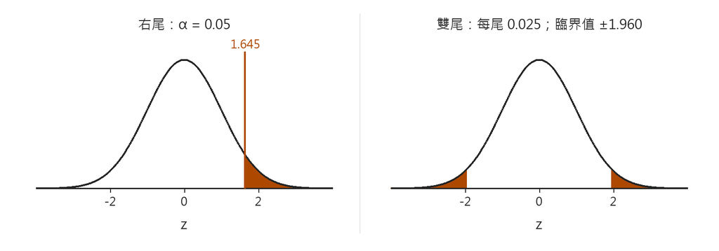

右尾檢定把5%放在右側；雙尾檢定把總共5%分到兩側。

- 單尾檢定（one-tailed test）：只把預先指定方向的偏離算進去。
- 雙尾檢定（two-tailed test）：兩個方向的偏離都重要。

IMS 2e §13.2.3、§14.2

## 方向與門檻，在看結果前決定

| 事前決定 | 理由 |
| --- | --- |
| 要比較的結果與參數 | 避免只挑最好看的結果 |
| 單尾或雙尾，以及方向 | 避免跟著觀察到的方向改假設 |
| 顯著水準 $\alpha$ | 避免看完 p 值（p-value）才移動門檻 |

探索資料後可以提出新假設，但要清楚區分探索與預先規劃的檢定。

**「希望結果下降」本身，不足以排除上升也值得關心的可能。**

IMS 2e §14.1–14.3、§22.2

## 一個量表案例，走完檢定流程

原教材的教學案例：64 位接受某介入者，介入後的憂鬱量表平均為 23 分。

| 給定資訊 | 數值 |
| --- | --- |
| 比較基準平均 $\mu_0$ | 25 分 |
| 假定已知的母體標準差（standard deviation）$\sigma$ | 6 分 |
| 樣本數 $n$ | 64 人 |
| 樣本平均 $\bar x$ | 23 分 |

$$H_0:\mu=25,\qquad H_1:\mu\ne25,\qquad \alpha=0.01$$

IMS 2e §19.2.1、§14.2

## 用 z 檢定之前，先確認條件

這個單一平均數的 z 檢定（one-sample z-test）假定：

- 各人的觀察值可視為獨立，樣本能支持所要推論的母體。
- 母體標準差 $\sigma=6$ 確實已知，而非把樣本標準差當成已知母體值。
- 母體為常態，或樣本平均的常態近似足夠合理。

**若 $\sigma$ 未知，須考慮估計標準誤與 t 方法；樣本大不會讓 $\sigma$ 自動變成已知。**

IMS 2e §19.2.1–19.2.3

## 平均差 2 分，要和多大的變動比較？

標準差描述個人分數的分散；標準誤（standard error, SE）描述樣本平均的抽樣變動。

$$SE(\bar X)=\frac{\sigma}{\sqrt n}=\frac{6}{\sqrt{64}}=0.75\ \text{分}$$

| 尺度 | 本例數值 |
| --- | --- |
| 個人分數的標準差 | 6 分 |
| 樣本平均的標準誤 | 0.75 分 |

**判斷平均差時，分母使用平均數的標準誤。**

IMS 2e §13.3.2、§19.2.1

## 觀察平均在基準下方 2.67 個標準誤

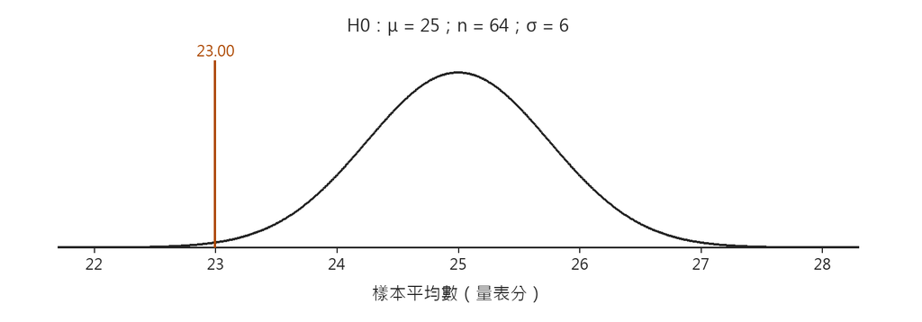

在虛無模型下，樣本平均以25分為中心；觀察到的23分標在左側。

$$z=\frac{\bar x-\mu_0}{SE}=\frac{23-25}{0.75}\approx-2.67$$

負號表示低於基準；極端程度還要依預先選定的尾端判斷。

IMS 2e §13.2.2、§19.2.1

## 雙尾 p 值：兩端的極端結果一起算

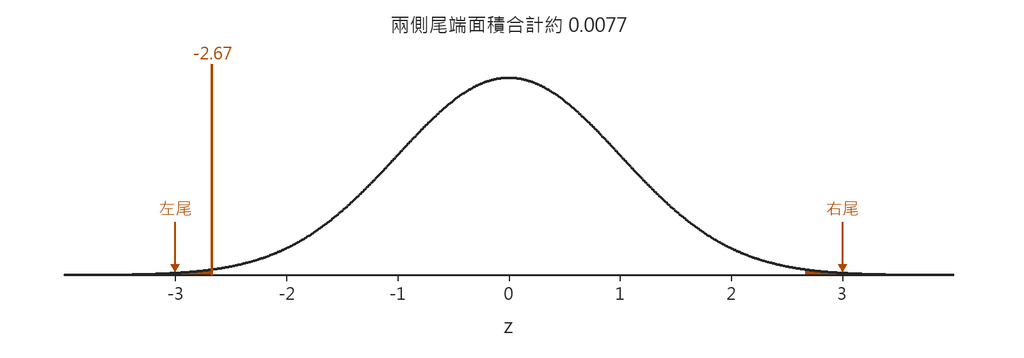

橘色兩尾包含z≤−2.67與z≥2.67；加總面積約為0.0077。

$$p=P_{H_0}(|Z|\ge|z_{\mathrm{obs}}|)\approx0.0077$$

**算的是「一樣或更極端」的尾端機率，不是剛好等於 −2.67 的機率。**

IMS 2e §11.3.2、§13.2.3、§14.2

## p 值的條件不能省略

p 值（p-value）回答的是：

若 $H_0$ 與模型條件成立，得到目前這麼極端或更極端統計量的機率。

| 本例可以說 | 不能改說成 |
| --- | --- |
| 在虛無模型下，雙尾機率約 .0077 | $H_0$ 為真的機率是 .77% |
| 資料與該模型的相容性較低 | 結果有 99.23% 的機率可重現 |

IMS 2e §11.3.2

## α 畫出規則；p 描述這次資料

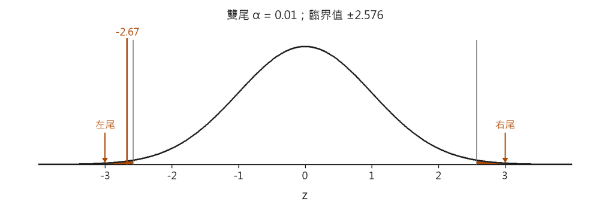

灰線標出雙尾α=.01的臨界值±2.576；觀察z=−2.67落在左側拒絕域。

顯著水準（significance level）$\alpha$ 在事前設定；臨界值（critical value）是對應門檻。

拒絕域（rejection region）：本例為 $z\le-2.576$ 或 $z\ge2.576$。

IMS 2e §13.2.3、§14.1–14.2

## 用 p 值或臨界值，得到相同決策

在同一模型、同一雙尾規則下：

| 比較方式 | 本例 |
| --- | --- |
| 比較 p 值與 $\alpha$ | $.0077<.01$ |
| 比較 $\|z\|$ 與正臨界值 | $2.67>2.576$ |
| 統計決策 | **拒絕 $H_0:\mu=25$** |

達到預定門檻，稱為統計顯著（statistically significant）。

**決策之後，還要把差的方向、大小與限制說清楚。**

IMS 2e §11.3.2、§14.1

## 結論要回到量表分數與比較基準

在已知母體標準差為 6 分等條件下，64 人的樣本平均為 23 分，比基準 25 分低 2 分；雙尾 z 檢定得到 $z=-2.67$、$p\approx.0077$，在 $\alpha=.01$ 下拒絕平均等於 25 分的假設。

- 這是與基準平均的比較，不是與同期隨機對照組的比較。
- 單憑這個案例，不能斷言介入造成分數下降。
- 是否有實質意義，還要結合量表脈絡與估計的不確定性。

IMS 2e §11.3.2、§16.1.1、§19.2.1

## 沒達門檻，結論就變成「完全相同」嗎？

若同樣低 2 分，但平均數的標準誤較大，證據可能不足以拒絕 $H_0$。

| 可以說 | 不能直接說 |
| --- | --- |
| 在本次資料與條件下，未拒絕 $H_0$ | 已證明 $H_0$ 為真 |
| 尚無足夠證據判斷偏離基準 | 已證明完全沒有差異 |

**未拒絕可能反映差異很小，也可能反映資料太不精確。**

IMS 2e §11.3.1、§14.4

## 統計顯著，不會一次回答所有問題

| 要回答的問題 | 還需要什麼？ |
| --- | --- |
| 差異有多大？ | 原始單位的差、效果量（effect size） |
| 估計有多精確？ | 標準誤、信賴區間（confidence interval） |
| 結果能否重現？ | 新資料、重複研究與研究品質 |
| 能否歸因於介入？ | 研究設計與混淆因素的評估 |

**p 值提供特定模型下的證據，不能取代以上資訊。**

IMS 2e §11.3.2、§12.3、§2.2

## 真實狀態與統計決策，可能不一致

| 真實狀態 | 未拒絕 $H_0$ | 拒絕 $H_0$ |
| --- | --- | --- |
| $H_0$ 為真 | 正確決策 | **型一錯誤** |
| $H_0$ 為假 | **型二錯誤** | 正確決策 |

- 型一錯誤（Type I error）：拒絕了真的 $H_0$。
- 型二錯誤（Type II error）：未拒絕假的 $H_0$。

**我們看得到決策，通常看不到當次研究的真實狀態。**

IMS 2e Ch14；Table 14.1

## α 控制的是長期誤拒絕率

假設 $H_0$ 為真，且模型與檢定條件成立。

若檢定的型一錯誤率為 .05，重複做 1,000 次這類研究，預期約 50 次會誤拒絕 $H_0$。

- 50 是長期預期，不保證每一批都剛好出現 50 次。
- 對某些離散或保守檢定，實際型一錯誤率可能低於設定的 $\alpha$。
- $\alpha=.05$ 不表示「這次顯著結果有 5% 的機率是錯的」。

IMS 2e §14.1、§14.3

## 檢定力，要指定「真實差異有多大」

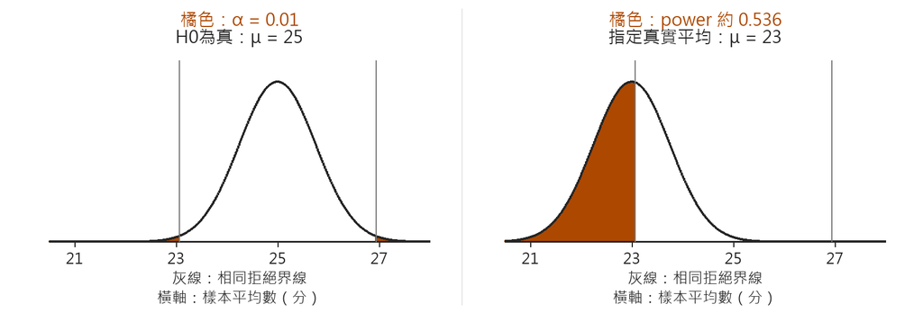

同一拒絕規則套到兩個分布：左圖看α，右圖在真實平均23分時看檢定力。

檢定力（power）$=1-\beta$：**在指定的真實效果下，拒絕 $H_0$ 的機率。**

$\beta$ 是在該效果下的型二錯誤率；本圖約為 $1-.536=.464$。

IMS 2e §14.4

## 把門檻變嚴格，也會改變漏掉差異的風險

固定樣本數、變異、真實效果與檢定方法，只降低 $\alpha$：

| 改變 | 通常帶來的結果 |
| --- | --- |
| 拒絕域縮小 | $H_0$ 為真時，較少誤拒絕 |
| 需要更極端的統計量 | $H_0$ 為假時，也較不容易拒絕 |
| 型一錯誤控制更嚴格 | 檢定力降低、$\beta$ 增加 |

**不能只追求較小的 α；也要規劃能辨認重要差異的資料量。**

IMS 2e §14.1、§14.4

## 什麼會影響辨認差異的能力？

其他條件相同時：

| 因素 | 對檢定力的一般影響 |
| --- | --- |
| 指定真實效果更大 | 較容易辨認 |
| 獨立觀察的樣本數增加 | 標準誤下降，較容易辨認 |
| 隨機變異或測量誤差減少 | 較容易辨認 |
| 顯著水準降低 | 門檻更嚴，較不容易辨認 |

**重複量同一人不等於新增同樣數量的獨立個體；設計與分析單位仍要一致。**

IMS 2e §14.4、§2.2.1

## 重抽樣之前，先分清楚要回答的問題

| 方法 | 重複產生什麼？ | 主要回答什麼？ |
| --- | --- | --- |
| 拔靴法（bootstrap）：原樣本直接取後放回 | 類似原樣本的新樣本 | 估計值有多不穩定？ |
| 從 $H_0$ 模型模擬 | 假設成立時的新資料 | 觀察統計量有多極端？ |
| 合乎設計的置換（permutation） | 在虛無條件下可交換的標籤 | 分組差異有多極端？ |

**拔靴法本身不會自動施加虛無假設，也不會自動修復偏誤。**

IMS 2e §23.1.1–23.1.2、§16.1.2

## 回到同分案例：在 15% 基準下產生資料

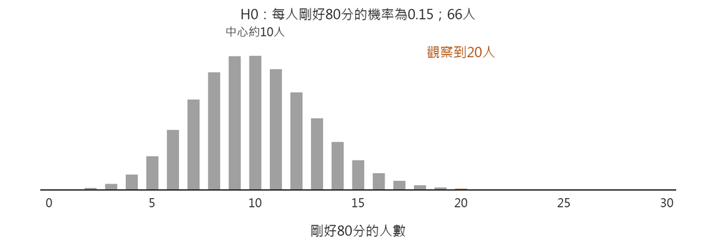

二項模型（binomial model）下，同分人數集中在約10人；觀察到20人位於右側。

- 每次產生 66 個結果，記錄其中「剛好 80 分」的人數。
- 保持 $H_0:\pi=.15$；依事前設定的極端程度與單雙尾規則計算 p 值。
- 不能直接以本次 30.3% 當生成機率，卻宣稱模擬的是 15% 基準。

IMS 2e §16.1.2–16.1.3

## 換成模擬或重抽樣，仍然要問條件

| 方法 | 不能省略的問題 |
| --- | --- |
| 本例的二項模型 | 每人結果可視為獨立、機率相同嗎？15%基準合理嗎？ |
| bootstrap | 原樣本能反映目標母體嗎？抽樣結構是否保留？ |
| 置換 | 哪些標籤在虛無條件下可以交換？配對有保留嗎？ |

**方法可以減少某些分布型態的要求，卻不會消除研究設計、抽樣與相依性的限制。**

IMS 2e §2.1.4、§13.5.4、§21.1

## 練習｜同一個 p 值，換門檻會怎樣？

某雙尾檢定得到 $p=.03$，樣本平均比基準低 2 分。

1. 若事前設定 $\alpha=.05$，統計決策是什麼？
2. 若事前設定 $\alpha=.01$，統計決策是什麼？
3. 兩種設定會讓「低 2 分」這個觀察差改變嗎？

**解析：**在 .05 下拒絕；在 .01 下未拒絕。觀察差與 p 值不變；變的是事前決策規則。不能看過 .03 才挑 .05。

IMS 2e §11.3.2、§14.1、§14.3

## 從研究問題走到可解讀的結論

**問題與母體參數** → $H_0$、$H_1$、單雙尾、$\alpha$

↓

**資料結構與模型條件** → 統計量、虛無分布、p 值

↓

**拒絕／未拒絕** → 差的大小、不確定性、錯誤風險與推論限制

**檢定是證據整理與決策的一部分；結論仍要回到原來的研究問題。**

IMS 2e §11.3、§14.1–14.4、§23.1–23.2

## Slido｜Week 7 Part 2

掃描 QR code，或至 [Slido](https://app.sli.do/event/x5omQqchQREmC2wRNXaHha) 輸入 **2244010**。

[figure not shown]

Week7 Slido活動QR code

## Slido 1｜假設談的是誰？

想知道某母體剛好得到 80 分的比例是否不同於 15%。哪個假設寫法正確？

1. $H_0$：這次樣本比例等於 15%。
2. $H_1$：這次觀察人數等於 20 人。
3. $H_0:\pi=.15$；$H_1:\pi\ne.15$。
4. $H_0:\pi>.15$；$H_1:\pi<.15$。

**答案：C。**假設針對母體參數；樣本是證據。D 漏掉等於 .15 的可能，並非完整互補。

IMS 2e §2.1.2、§11.3

## Slido 2｜p 值中的「假如」

雙尾檢定得到 $p=.008$，哪個解讀正確？

1. $H_0$ 為真的機率是 .8%。
2. 若 $H_0$ 與模型條件成立，得到同樣或更極端統計量的機率為 .8%。
3. 本次結論有 .8% 的機率是錯的。
4. 下次研究有 99.2% 的機率重現。

**答案：B。**p 值以 $H_0$ 與模型條件成立為前提，不是給定資料後的假設機率或重現機率。

IMS 2e §11.3.2

## Slido 3｜哪一個是型一錯誤？

令 $H_0$ 為「母體平均差為 0」。哪個情況是型一錯誤？

1. 真實平均差為 0，且未拒絕 $H_0$。
2. 真實平均差不為 0，卻未拒絕 $H_0$。
3. 真實平均差不為 0，且拒絕 $H_0$。
4. 真實平均差為 0，卻拒絕 $H_0$。

**答案：D。**型一錯誤是拒絕真的 $H_0$；B 是型二錯誤。

IMS 2e Ch14；Table 14.1